# Pitching Order Splits

10/30/2020

### **Data Collection**

First, we need data. Using MLB’s StatCast and the *baseballr* package, I pulled pitching data for the 2019 and shortened 2020 regular seasons. The data pulled from the query below includes every atbat, or *event*, in every game from these two seasons. Initially, every pitch is returned, which, along with returning an absurd amount of data, is not important to us. We filter the results such that only the result of the atbat is stored using the comparison `events != null`.

```r
### PULL DATA
events_2020 <-NULL
dates <- seq(as.Date("2019-4-01"), as.Date("2019-09-27"), by="days")
for(i in 1:length(dates)){
  print(dates[i])
  day <- scrape_statcast_savant(start_date = dates[i],
                                        end_date = dates[i],
                                        playerid = NULL,
                                        player_type = "pitcher") %>% filter(events != 'null') #track only events, not pitches
  events_2020 <-rbind(events_2020,day)
}
```

The data returned looks like below. Each row is an atbat, and all atbats are stored in reverse chronological order, (although we will flip the data to chronological, as it is easier to work with this way.) There are many, many more columns, but we do not need to work with most of them for our purposes.

```
##   pitch_type  game_date release_speed   player_name    events game_pk inning
## 1         CH 2020-09-01          87.7 Wandy Peralta field_out  631528      9
## 2         CH 2020-09-01          87.0 Wandy Peralta   sac_fly  631528      9
## 3         FF 2020-09-01          95.3 Wandy Peralta      walk  631528      9
## 4         SI 2020-09-01          92.5  Seth Elledge field_out  631586      9
## 5         SL 2020-09-01          86.7 Wandy Peralta strikeout  631528      9
## 6         SI 2020-09-01          94.9 Wandy Peralta    single  631528      9
```

### **The Process**

Now that we have our data, we need to think about what our process is going to look like. Generally the idea is to,

1. For each game:
   1. Find the starting pitchers.
   2. Track the number of atbats completed and hits allowed in their first, second, and third times through the order.
   3. Calculate each starter’s BAA in each order split.
2. Find the mean/average of each order split.
3. Run statistical comparisons of the three splits.

Pretty straightforward, lets do it.

##### **Finding Each Game**

Each game has a unique ID number, `game_pk`, so we use this to iterate over each game in our dataset. The variable `lastgame` holds the data of the game we are currently analyzing, (in retrospect maybe my naming convention could’ve been a bit better.)

```r
  #set curr game
  lastgame <- events_2020 %>% filter(game_pk == i)
```

##### **Locating the Starters**

There is no explicit way to determine who the starters are for a game from our data. Finding the home starter is easy—find the first player to throw a pitch. But, the away starter is not guaranteed to be the second pitcher the game. If Drew Pomeranz gets absolutely shelled and can’t finish the first inning, our selection would be incorrect. We need to find the next pitcher who is not on the same team as the home starter. To do this we can use the `inning_topbot` variable, which signifies if an event took place in the top or bottom of the inning. The away starter will be the next pitcher who is not pitching in the top of an inning.

```r
  sp_home<-lastgame[1,] ##select home starter

  #find away starter
  sp_away <-sp_home
  k=2
  while(sp_away$player_name == sp_home$player_name){
    sp_away <- lastgame[k,]
    k=k+1
    #dont update if second pitcher is from same team as the first
    if(sp_away$inning_topbot == sp_home$inning_topbot){
      sp_away <- sp_home
    }
  }
```

##### **Tracking Hits, Calculating BAA**

```r
    pitchers <-c(sp_home$player_name, sp_away$player_name)
    for(j in pitchers){
      #select starter
      temp_pitcher <- lastgame %>% filter(player_name == j) ##find all atbats for curr pitcher
      bf <- nrow(temp_pitcher) ##batters faced for curr pitcher

      if(bf > 18){
        batters_faced <-c(batters_faced, bf) ##total counter of pitchers who faced 18 batters

        count = count + 1
        ##collection and aggregation
        total_ab_1 <- c(total_ab_1, get_abs(temp_pitcher[1:9,]))
        total_hits_1 <-c(total_hits_1, get_hits(temp_pitcher[1:9,]))
        total_ab_2 <- c(total_ab_2, get_abs(temp_pitcher[10:18,]))
        total_hits_2 <-c(total_hits_2, get_hits(temp_pitcher[10:18,]))
        total_ab_3 <- c(total_ab_3, get_abs(temp_pitcher[19:bf,]))
        total_hits_3 <-c(total_hits_3, get_hits(temp_pitcher[19:bf,]))
      }
    }
    total_oba_1 <- total_hits_1 / total_ab_1
    total_oba_2 <- total_hits_2 / total_ab_2
    total_oba_3 <- total_hits_3 / total_ab_3
}
```

Where `get_hits` and `get_abs` are functions defined as,

```r
get_hits <-function(pitcher){
  nrow(pitcher %>% filter(events %in% c("single", "double", "triple", "home_run")))
}
get_abs <-function(pitcher){
  nrow(pitcher) - nrow(pitcher %>% filter(events %in% c("walk","sac_fly","sac_bunt","hit_by_pitch")))
}
```

#### **Analysis**

With the BAAs calculated, we’re now ready to start analyzing.

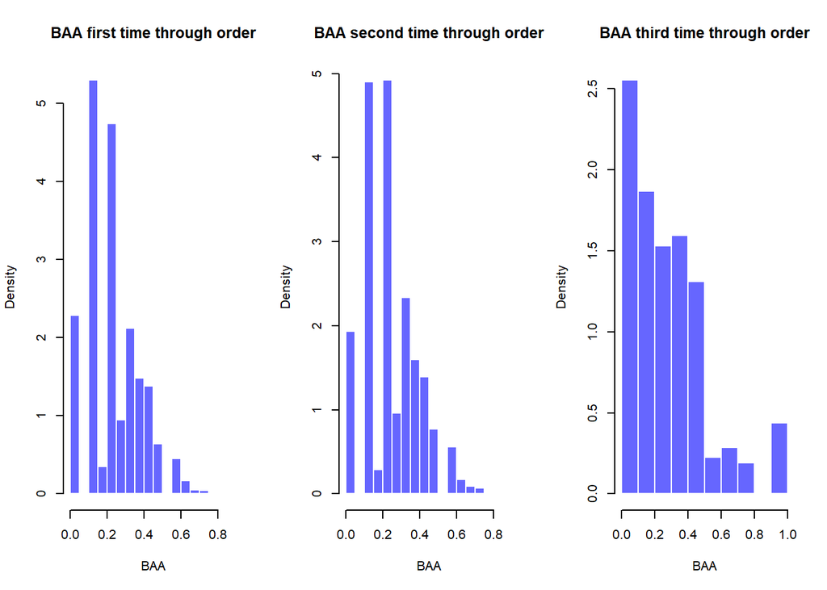

```r
for(i in 1:5000){
  oba_1_mean<- c(oba_1_mean,mean(sample(total_oba_1, length(total_oba_1), replace = T),na.rm = TRUE))
  oba_3_mean<- c(oba_3_mean,mean(sample(total_oba_3, length(total_oba_3), replace = T),na.rm = TRUE))
  oba_2_mean<- c(oba_2_mean,mean(sample(total_oba_2, length(total_oba_2), replace = T),na.rm = TRUE))
  ##diff
  oba_diff2<-c(oba_diff2,mean(sample(total_oba_1, length(total_oba_1), replace = T),na.rm = TRUE) - mean(sample(total_oba_3, length(total_oba_3), replace = T),na.rm = TRUE))
  oba_diff3 <-c(oba_diff3,mean(sample(total_oba_1, length(total_oba_1), replace = T),na.rm = TRUE) - mean(sample(total_oba_2, length(total_oba_2), replace = T),na.rm = TRUE))
}
```

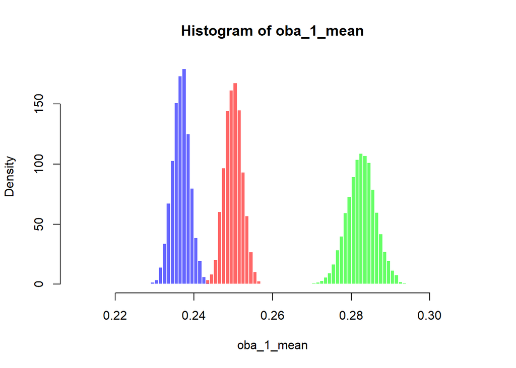

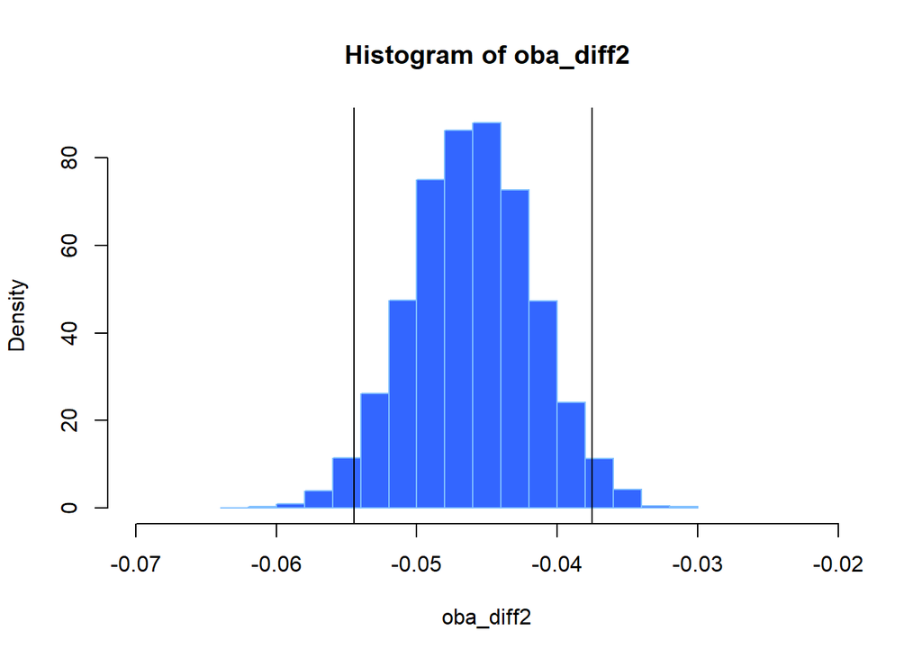

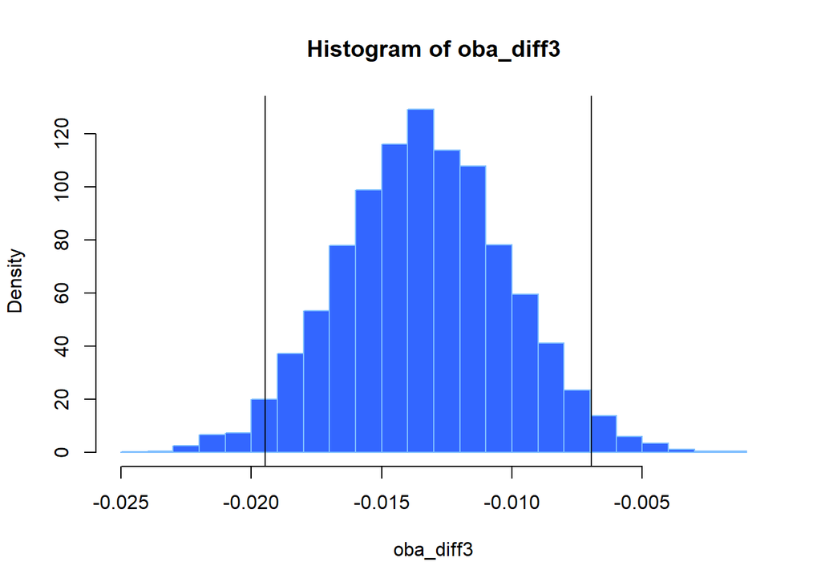